# Actividad física, zonas verdes y salud mental

Vera García Díez y Sara González Bárcena

09 diciembre 2021

## Objetivo General

Analizar si existe alguna relación entre la realización de actividad física a mayor satisfacción de zonas verdes y la salud mental de las personas.

Los datos han sido obtenidos del *Instituto Nacional de Estadística (INE)*.

- **Satisfacción con las zonas verdes por CCAA y nivel de satisfacción** [satisfaccion_zonas_verdes](https://www.ine.es/jaxi/Datos.htm?path=/t00/ICV/dim8/&file=82101.px)
- **Enfermedades crónicas** [enfermedades_cronicas](https://www.ine.es/jaxiT3/Datos.htm?tpx=47669)
- **Número de días por semana de ejercicio físico según sexo y cCCAA. Población de 15 y más años** [ejercicio_fisico](https://www.ine.es/jaxiT3/Datos.htm?tpx=47605)

### Tabla modificada de satisfacción de las zonas verdes por CCA.

```r
ZV <- zonasVerdes %>%
  slice(2:20) %>%
  rename(comunidades = ...1, Valoracion = `Valoración media`)
```

|  | comunidades | De 0 a 4 | De 5 a 6 | De 7 a 8 | De 9 a 10 | Valoracion |
| --- | --- | --- | --- | --- | --- | --- |
| 1 | Andalucía | 21.4 | 27 | 33 | 18.6 | 6.3 |
| 2 | Aragón | 14.3 | 24.5 | 42.1 | 19.1 | 6.7 |
| 3 | Asturias, Principado de | 4.8 | 15.1 | 49.8 | 30.3 | 7.6 |
| 4 | Balears, Illes | 15.3 | 21.6 | 37 | 26 | 6.7 |
| 5 | Canarias | 22 | 31.1 | 36.4 | 10.5 | 5.9 |
| 6 | Cantabria | 10.5 | 19.2 | 47.7 | 22.5 | 7.1 |
| 7 | Castilla y León | 6.7 | 23.9 | 48.5 | 20.9 | 7.1 |
| 8 | Castilla - La Mancha | 10.6 | 22.4 | 46.1 | 20.8 | 6.9 |
| 9 | Cataluña | 7.8 | 27.6 | 47.4 | 17.1 | 6.9 |
| 10 | Comunitat Valenciana | 13.8 | 25.9 | 41.3 | 19 | 6.7 |

[output cut: 9 more lines]

### Tabla modificada enfermedades crónicas, ansiedad y depresión, por CCAA y porcentaje de personas.

```r
SM <- saludMental %>%
  rename(Comunidades = "Ambos sexos", depresión = ...60, ansiedad = ...63) %>%
  pivot_longer(names_to = "Enfermedades", values_to = "SM_pers", cols = c(depresión, ansiedad)) %>%
  slice(c(3:44)) %>%
  select(c(1,96,97))
```

|  | Comunidades | Enfermedades | SM_pers |
| --- | --- | --- | --- |
| 1 | Andalucía | depresión | 4.63 |
| 2 | Andalucía | ansiedad | 4.72 |
| 3 | Aragón | depresión | 3.57 |
| 4 | Aragón | ansiedad | 4.71 |
| 5 | Asturias, Principado de | depresión | 9.13 |
| 6 | Asturias, Principado de | ansiedad | 6.78 |
| 7 | Balears, Illes | depresión | 6.8 |
| 8 | Balears, Illes | ansiedad | 7.55 |
| 9 | Canarias | depresión | 6.92 |
| 10 | Canarias | ansiedad | 9.69 |

[output cut: 32 more lines]

### Tabla modificada con la frecuencia de actividad física a la semana por CCAA.

```r
AF <-
actFisica %>%
  slice(3:21) %>%
  rename(Comunidades = ...1, d1_2 = `1 o 2 días a la semana`,
         d3_4 = `3 o 4 días a la semana`,
         d5_6 = `5 o 6 días a la semana`,
         d7 = `7 días a la semana`) %>%
  select(c(1,2,4:7)) %>%
  pivot_longer(names_to = "Frecuencia", values_to = "AF_pers", cols = c(`d1_2`:`d7`))
```

|  | Comunidades | TOTAL | Frecuencia | AF_pers |
| --- | --- | --- | --- | --- |
| 1 | Andalucía | 7096.4 | d1_2 | 825.6 |
| 2 | Andalucía | 7096.4 | d3_4 | 1318.7 |
| 3 | Andalucía | 7096.4 | d5_6 | 755.2 |
| 4 | Andalucía | 7096.4 | d7 | 478 |
| 5 | Aragón | 1121.4 | d1_2 | 144.1 |
| 6 | Aragón | 1121.4 | d3_4 | 179.8 |
| 7 | Aragón | 1121.4 | d5_6 | 101.9 |
| 8 | Aragón | 1121.4 | d7 | 91 |
| 9 | Asturias, Principado de | 896.9 | d1_2 | 161.8 |
| 10 | Asturias, Principado de | 896.9 | d3_4 | 201.6 |

[output cut: 66 more lines]

Vista general de la frecuencia de actividad físca. La mayoría de la gente realiza ejercicio 3 o 4 días a la semana.

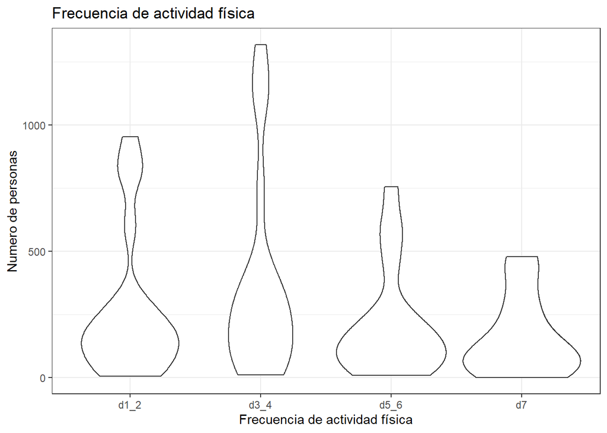

```r
grafico <- AF%>%
  ggplot(data = ., aes(x = Frecuencia, y = AF_pers)) +
  geom_violin(aes(fill=AF_pers))+
  theme_bw() +
  labs(
    x = "Frecuencia de actividad física",
    y = "Numero de personas",
    title = "Frecuencia de actividad física ",
    colour = "Comunidades Autónomas"
  )
```

## Objetivos específicos

### 1. Relación actividad física y zonas verdes

Análisis sobre a mayor porcentaje de áreas verdes, más personas realizan actividad física.

```r
AF_ZV <-
  AF %>%
  select(Comunidades, Frecuencia, AF_pers) %>%
  full_join(x = .,
            y = ZV %>%
              select(comunidades, Valoracion),
            by = c("Comunidades" = "comunidades"))
```

|  | Comunidades | Frecuencia | AF_pers | Valoracion |
| --- | --- | --- | --- | --- |
| 1 | Andalucía | d1_2 | 825.6 | 6.3 |
| 2 | Andalucía | d3_4 | 1318.7 | 6.3 |
| 3 | Andalucía | d5_6 | 755.2 | 6.3 |
| 4 | Andalucía | d7 | 478 | 6.3 |
| 5 | Aragón | d1_2 | 144.1 | 6.7 |
| 6 | Aragón | d3_4 | 179.8 | 6.7 |
| 7 | Aragón | d5_6 | 101.9 | 6.7 |
| 8 | Aragón | d7 | 91 | 6.7 |
| 9 | Asturias, Principado de | d1_2 | 161.8 | 7.6 |
| 10 | Asturias, Principado de | d3_4 | 201.6 | 7.6 |

[output cut: 66 more lines]

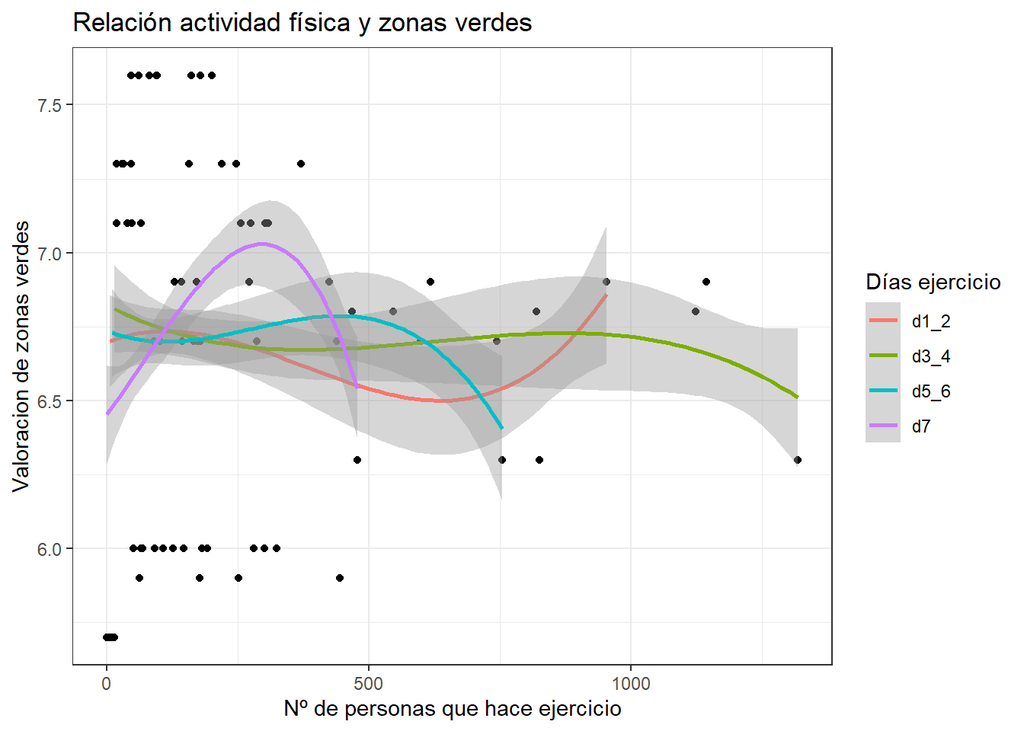

```r
grafico1 <- AF_ZV %>%
  filter(Valoracion > 4) %>%
  ggplot(data = ., aes(x = AF_pers, y = Valoracion)) +
  geom_point() +
  #geom_smooth(method = "lm", aes(colour = factor(Frecuencia)), level = 0.3) +
  geom_smooth(method = "lm", formula = y~poly(x, 3), aes(colour = factor(Frecuencia)), level = 0.3) +
  theme_bw() +
  labs(
    x = "Nº de personas que hace ejercicio",
    y = "Valoracion de zonas verdes",
    title = "Relación actividad física y zonas verdes ",
    colour = "Días ejercicio"

  )
```

### 1.1. Conclusión:

*(intentaría cambiar los nombres de los niveles, ya que `d1_2` es poco entendible. A lo mejor lo que tenéis acá es simplemente un gradiente de ejercicio, desde `Nada` hasta `Mucho` y en métodos explicáis qué significa cada uno (`d1_2` es poco ejercicio)).

Desde casa se ve todo mejor.

### 2. Relación actividad física y salud mental

Análisis sobre a mayor frecuencia de actvidad física, disminuye la población que padece depresión y ansiedad.

```r
AF_SM <-
  AF %>%
  select(Comunidades, Frecuencia, AF_pers) %>%
  full_join(x = .,
            y = SM %>%
              select(Comunidades, Enfermedades, SM_pers),
            by = "Comunidades") %>%
  drop_na()
```

|  | Comunidades | Frecuencia | AF_pers | Enfermedades | SM_pers |
| --- | --- | --- | --- | --- | --- |
| 1 | Andalucía | d1_2 | 825.6 | depresión | 4.63 |
| 2 | Andalucía | d1_2 | 825.6 | ansiedad | 4.72 |
| 3 | Andalucía | d3_4 | 1318.7 | depresión | 4.63 |
| 4 | Andalucía | d3_4 | 1318.7 | ansiedad | 4.72 |
| 5 | Andalucía | d5_6 | 755.2 | depresión | 4.63 |
| 6 | Andalucía | d5_6 | 755.2 | ansiedad | 4.72 |
| 7 | Andalucía | d7 | 478 | depresión | 4.63 |
| 8 | Andalucía | d7 | 478 | ansiedad | 4.72 |
| 9 | Aragón | d1_2 | 144.1 | depresión | 3.57 |
| 10 | Aragón | d1_2 | 144.1 | ansiedad | 4.71 |

[output cut: 142 more lines]

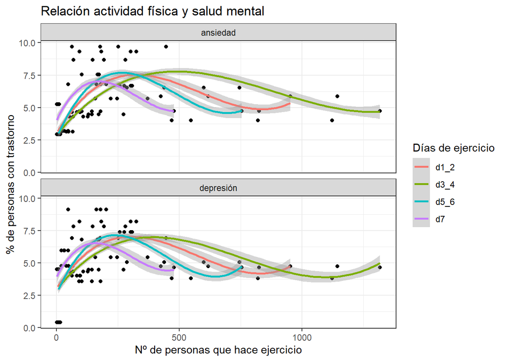

```r
grafico2 <- AF_SM %>%
  ggplot(data = ., aes(x = AF_pers, y = SM_pers)) +
  geom_point() +
  geom_smooth(method = "lm", formula = y~poly(x, 3), aes(colour = factor(Frecuencia)), level = 0.3) +
  theme_bw() +
  facet_wrap( ~ Enfermedades, nrow = 2) +
  labs(
    x = "Nº de personas que hace ejercicio",
    y = "% de personas con trastorno",
    title = "Relación actividad física y salud mental ",
    colour = "Días de ejercicio"

  )
```

### 2.1. Conclusión:

*(Re-interpretar las conclusiones ya que el modelo elegido probablemente no estaba contando “todo el cuento”)

### 3. Relación salud mental y zonas verdes

Análisis sobre si disminuye las personas con ansiedad o depresión a mayor zonas verdes.

```r
ZV_SM <-
  ZV %>%
  select(comunidades, Valoracion) %>%
  full_join(x = .,
            y = SM %>%
              select(Comunidades, Enfermedades, SM_pers),
            by = c("comunidades" = "Comunidades"))
```

|  | comunidades | Valoracion | Enfermedades | SM_pers |
| --- | --- | --- | --- | --- |
| 1 | Andalucía | 6.3 | depresión | 4.63 |
| 2 | Andalucía | 6.3 | ansiedad | 4.72 |
| 3 | Aragón | 6.7 | depresión | 3.57 |
| 4 | Aragón | 6.7 | ansiedad | 4.71 |
| 5 | Asturias, Principado de | 7.6 | depresión | 9.13 |
| 6 | Asturias, Principado de | 7.6 | ansiedad | 6.78 |
| 7 | Balears, Illes | 6.7 | depresión | 6.8 |
| 8 | Balears, Illes | 6.7 | ansiedad | 7.55 |
| 9 | Canarias | 5.9 | depresión | 6.92 |
| 10 | Canarias | 5.9 | ansiedad | 9.69 |

[output cut: 32 more lines]

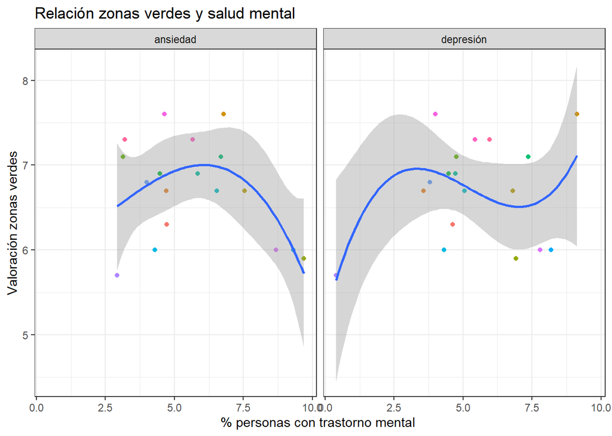

```r
grafico3 <- ZV_SM %>%
  filter(Valoracion > 4) %>%
  ggplot(data = ., aes(x = SM_pers, y = Valoracion)) +
  geom_point(aes(colour = factor(comunidades)),
             show.legend = FALSE) +
  geom_smooth(method = "lm", formula = y~poly(x, 3)) +
  theme_bw() +
  facet_wrap( ~ Enfermedades, nrow = 1) +
  labs(
    x = "% personas con trastorno mental ",
    y = "Valoración zonas verdes",
    title = "Relación zonas verdes y salud mental ",
    colour = "Comunidades Autónomas"

  )
```

### 3.1. Conclusión:

No se aprecia una relación significativa. Ya que se observa una distribución homogenea.

En relación a depresión:

- No se aprecia una distribución concreta.

### 4. Conclusión general:

Lo esperable es que a mayor satisfacción de zonas verdes, la gente realiza más ejercicio.

Por otra parte, lo más logico es que a valores medios de ejercicio físico las personas sean “sanas”, y a niveles extremos de ejercicio, es decir, mayor y menor actividad física, deberían presentar ansiedad y/o depresión.

El resultado obtenido no concuerda para nada con lo esperado.

Por último, entre la sastisfacción de zonas verdes y la salud mental no presentan relación alguna. Bajo nuestro punto de vista, cuanto mayor sea la satisfacción de las personas menos enfermedades mentales padecen. Porque pueden salir con más frecuencia a la calle, cuanto mejor sea el mantenimiento de parques y jardines es más apetecible salir.